# Step Generation

### 1.3.3 Strata Coverage

We’ll only include the localisations of moose that mostly stick to the strata in a season. For example, occasionally there is a moose that spends 50% of its time in one strata and 50% in another (although quite rare as we see in a bit). This would cause a small / unrepresentative number of localisations for an individual in a strata, therefore we remove them.

```
In [14]:
```

```r
threshold = 0.7 # at least 70% of fixes required to be in the dominant strata in a season
```

```
In [15]:
```

```r
strata_coverage <- moose %>%
  # First get the amount of fixes for each unique season and strata
  group_by(animal_id, season_year, season, strata) %>%
  summarise(strata_fixes = n(), .groups = "drop") %>%
  group_by(animal_id, season_year, season) %>%
  # Then see what proportion of the season's fixes were in each strata
  mutate(
    total_fixes = sum(strata_fixes),
    strata_percentage = strata_fixes / total_fixes
  )
```

```
In [16]:
```

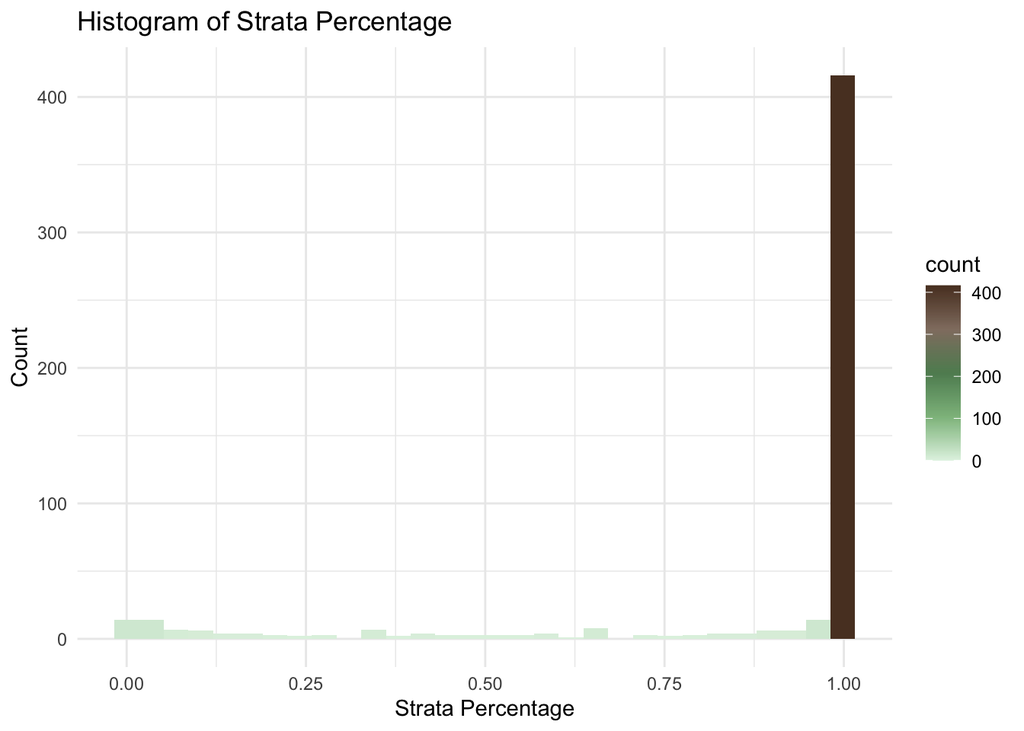

```r
ggplot(strata_coverage, aes(x=strata_percentage)) +
  geom_histogram(aes(fill = ..count..)) +
  scale_fill_gradientn(colors = greens_to_browns(100)) +
  labs(title = "Histogram of Strata Percentage", x = "Strata Percentage", y = "Count") +
  theme_minimal()
```

```
In [17]:
```

```r
# Filter animals where the dominant strata has at least 70% of localizations
strata_coverage <- strata_coverage %>%
  filter(strata_percentage >= threshold)

# Keep only localizations within the dominant strata
moose <- moose %>%
  inner_join(
    strata_coverage %>% select(animal_id, season_year, season, strata),
    by = c("animal_id", "season_year", "season", "strata")
  )
```

```
In [18]:
```

```r
# Percentages per Strata
table(moose$strata)
```

```
boreal alpine  boreal coast boreal inland     temperate
       163034         55201         29558         79505
```

## 1.4 Plot Localisations

```
In [19]:
```

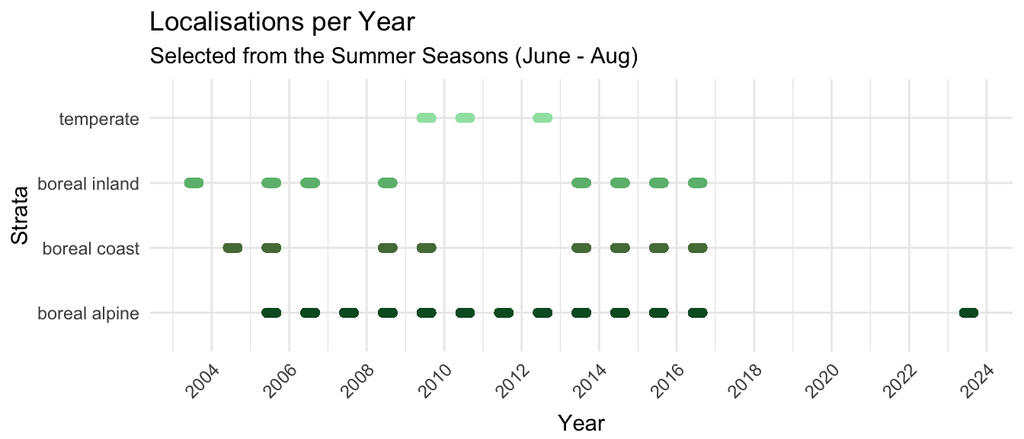

```r
plot1 <- moose %>% ggplot(aes(x = date, y = factor(strata), colour = factor(strata))) +
  geom_point() +
  scale_y_discrete("Strata") +
  scale_x_datetime("Year", date_breaks="2 years", date_labels="%Y") +
  scale_color_manual(
    values = c(
    "temperate" = lightgreen,
    "boreal inland" = green,
    "boreal coast" = mossgreen,
    "boreal alpine" = darkgreen
  )) +
  theme_minimal() +
  theme(
    axis.title.x = element_text(vjust=-0.5),
    axis.text.x = element_text(angle = 45, vjust = 1, hjust=1),
    legend.position = "none"
  ) +
  labs(title="Localisations per Year", subtitle="Selected from the Summer Seasons (June - Aug)")
ggsave('figures/01_localisations_per_year.jpg', height=3, width=7)
plot1
```

# 2 - Create tracks and (random) steps

## 2.1 Create tracks and bursts

Now we create the tracks using the `amt` package.

We’ll also re-project from EPSG:4326 to EPSG:3006 (SWEFREFF-99), the current standard CRS of Sweden.

```
In [20]:
```

```r
moose_tracks <- moose %>% mk_track(id = animal_id,
                                   .x=x,
                                   .y=y,
                                   .t=date,
                                   all_cols = T,
                                   crs = 4326) %>%
  transform_coords(crs_to = 3006, crs_from = 4326)
```

```
In [21]:
```

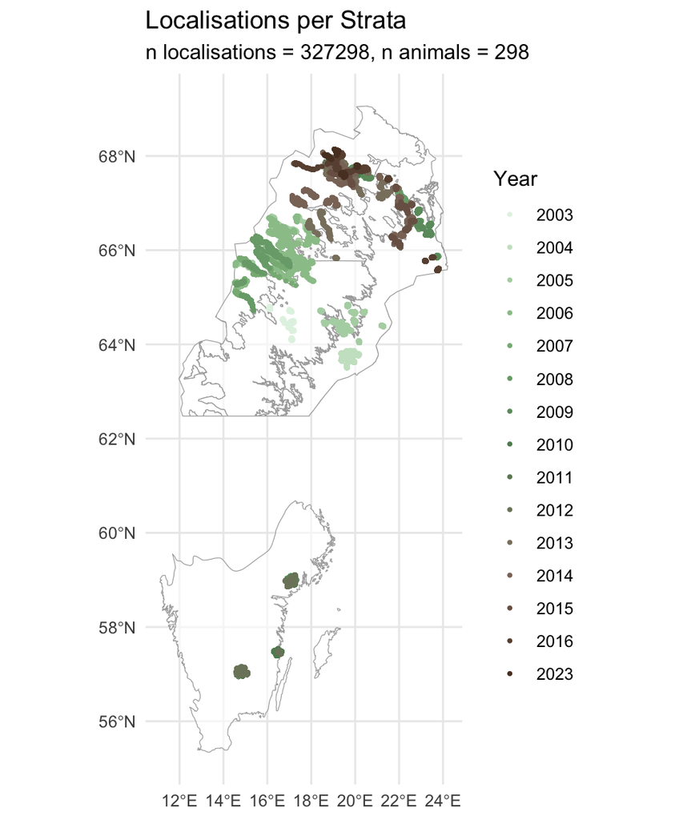

```r
n_localisations = nrow(moose_tracks)
n_animals = length(unique(moose_tracks$animal_id))
n_years <- length(unique(moose_tracks$year))

custom_green_brown <- greens_to_browns(n_years)

# plot the data, spatially colored by year
moose_sf <- st_as_sf(moose_tracks, coords=c("x_", "y_"), crs=st_crs(3006))
plot2 <- ggplot() +
  layer_spatial(strata, fill="transparent", color="darkgrey", size=0.1, alpha=0.6) +
  layer_spatial(moose_sf, size=0.6, aes(color=as.factor(year))) +
  scale_color_manual(name="Year", values = custom_green_brown) +
  labs(
    title="Localisations per Strata",
    subtitle=glue("n localisations = {n_localisations}, n animals = {n_animals}")
  ) +
  theme_minimal()
ggsave('figures/01_localisations_per_strata.jpg')
plot2
```

```
In [22]:
```

```r
# TODO remove when lubridate fixes this
round_to_hour <- function(dt) {
  # Extract components
  hr <- hour(dt)
  min <- minute(dt)
  sec <- second(dt)

  # Determine if rounding up is needed
  round_up <- min > 30 | (min == 30 & sec > 0)

  # Apply rounding: If rounding up, add an hour and set min/sec to 0
  dt <- floor_date(dt, "hour") + dhours(round_up)

  return(dt)
}
```

```
In [23]:
```

```r
# nest the data by individual
moose_steps <- moose_tracks %>% arrange(animal_id) %>% nest(data = -"animal_id")

moose_steps_by_burst <- moose_steps %>%
  mutate(steps = map(data, function(x)
    x %>% track_resample(rate = hours(3), tolerance = minutes(10)) %>%
      # to filter out bursts with less than 3 locations
      amt::filter_min_n_burst(min_n = 3) %>%
      steps_by_burst(keep_cols='start')))

# unnest the data after creating 'steps' objects
moose_steps_by_burst <- moose_steps_by_burst %>%
  amt::select(animal_id, steps) %>%
  amt::unnest(cols = steps)

moose_steps_by_burst <- moose_steps_by_burst %>%
  mutate(
    # round the time to the nearest hour
    t1_ = round_to_hour(t1_),
    t2_ = round_to_hour(t2_),
    # change the 0 hour to 24
    hour_t1 = ifelse(hour(t1_) == 0, 24, hour(t1_)),
    hour_t2 = ifelse(hour(t2_) == 0, 24, hour(t2_))
  )

head(moose_steps_by_burst, 10)
```

```
# A tibble: 10 × 23
   animal_id        x1_    x2_    y1_    y2_    sl_ direction_p    ta_ collar_id
 * <chr>          <dbl>  <dbl>  <dbl>  <dbl>  <dbl>       <dbl>  <dbl> <chr>
 1 aa_ac_03_003 597045. 5.97e5 7.18e6 7.18e6 5.13e0       1.60  NA     VAS_00424
 2 aa_ac_03_003 597044. 5.97e5 7.18e6 7.18e6 1.64e2      -3.08   1.60  VAS_00424
 3 aa_ac_03_003 596880. 5.96e5 7.18e6 7.18e6 1.74e3       2.17  -1.04  VAS_00424
 4 aa_ac_03_003 595905. 5.96e5 7.18e6 7.18e6 1.87e2       1.82  -0.345 VAS_00424
 5 aa_ac_03_003 595858. 5.96e5 7.18e6 7.18e6 7.69e1      -0.434 -2.25  VAS_00424
 6 aa_ac_03_003 595928. 5.96e5 7.18e6 7.18e6 7.91e1       0.101  0.535 VAS_00424
 7 aa_ac_03_003 596007. 5.96e5 7.18e6 7.18e6 1.49e2      -0.130 -0.231 VAS_00424
 8 aa_ac_03_003 596155. 5.96e5 7.18e6 7.18e6 9.30e1      -1.43  -1.30  VAS_00424
 9 aa_ac_03_003 596168. 5.96e5 7.18e6 7.18e6 5.01e1      -1.86  -0.427 VAS_00424
10 aa_ac_03_003 596153. 5.96e5 7.18e6 7.18e6 8.91e1      -2.00  -0.136 VAS_00424
# ℹ 14 more variables: collar_temperature <int>, birth_year <int>, long <dbl>,
#   lat <dbl>, strata <fct>, year <dbl>, season <chr>, season_year <dbl>,
#   burst_ <dbl>, t1_ <dttm>, t2_ <dttm>, dt_ <drtn>, hour_t1 <dbl>,
#   hour_t2 <dbl>
```

## 2.2 Fit step-length and turning-angle distributions for each strata

Lets fit a gamma distribution for step length, and a von Mises distribution for turning angle for the moose localisations in every strata. We do this on the population level as that makes correcting the selection-free movement kernel later on easier. We do divide the population into four sub-populations for each strata, as there are clear differences in step-length between boreal and temperate moose populations.

The distribution parameters will be important later on when we correct the selection-free movement kernel, so print them here.

```
In [24]:
```

```r
moose_steps_by_burst <- moose_steps_by_burst %>%
  mutate(sl_ = if_else(sl_ < 0.1, 0.1, sl_))
```

```
In [25]:
```

```r
# Fit distributions for each strata
dist_params <- moose_steps_by_burst %>%
  group_by(strata) %>%
  summarise(
    gamma_shape = fit_distr(sl_, "gamma")$params$shape,
    gamma_scale = fit_distr(sl_, "gamma")$params$scale,
    vonmises_kappa = fit_distr(ta_, "vonmises")$params$kappa,
    vonmises_mu = fit_distr(ta_, "vonmises")$params$mu,
    .groups = "drop"
  )
# Display table of parameters
print(dist_params)
```

```
# A tibble: 4 × 5
  strata        gamma_shape gamma_scale vonmises_kappa vonmises_mu
  <fct>               <dbl>       <dbl>          <dbl> <circular>
1 boreal alpine       0.675        382.         0.177  0
2 boreal coast        0.774        273.         0.0262 0
3 boreal inland       0.739        347.         0.126  0
4 temperate           0.875        191.         0.0723 0
```

## 2.3 Generate random steps for each strata (population)

```
In [26]:
```

```r
# we'll keep the top 15 later
number_of_random_steps = 30
```

```
In [27]:
```

```r
moose_random_steps <- moose_steps_by_burst %>%
  group_split(strata) %>%
   map_dfr(~ {
    # Fit distributions for this subset
    gamma_dist <- fit_distr(.x$sl_, "gamma")
    vonmises_dist <- fit_distr(.x$ta_, "vonmises")
    class(.x) <- class(moose_steps_by_burst)
    # Generate random steps
    .x %>%
      random_steps(n_control = number_of_random_steps,
                   sl_distr = gamma_dist,
                   ta_distr = vonmises_dist) %>%
      mutate(y = as.numeric(case_))
  })
moose_random_steps <- remove_incomplete_strata(moose_random_steps, col = "ta_")
print(moose_random_steps)
```

```
# A tibble: 9,797,581 × 25
   animal_id        x1_     x2_      y1_      y2_   sl_    ta_ collar_id
 * <chr>          <dbl>   <dbl>    <dbl>    <dbl> <dbl>  <dbl> <chr>
 1 aa_ac_04_028 509475. 509485. 7280977. 7280973.  10.1 -1.45  VAS_01025
 2 aa_ac_04_028 509475. 509459. 7280977. 7280979.  16.7  1.86  VAS_01025
 3 aa_ac_04_028 509475. 509527. 7280977. 7281166. 196.   0.184 VAS_01025
 4 aa_ac_04_028 509475. 509514. 7280977. 7280985.  39.9 -0.913 VAS_01025
 5 aa_ac_04_028 509475. 509355. 7280977. 7280895. 146.   2.62  VAS_01025
 6 aa_ac_04_028 509475. 509483. 7280977. 7280963.  16.0 -2.18  VAS_01025
 7 aa_ac_04_028 509475. 509810. 7280977. 7280607. 499.  -1.96  VAS_01025
 8 aa_ac_04_028 509475. 509375. 7280977. 7281329. 367.   0.724 VAS_01025
 9 aa_ac_04_028 509475. 509267. 7280977. 7281018. 212.   1.82  VAS_01025
10 aa_ac_04_028 509475. 509455. 7280977. 7280563. 414.  -2.74  VAS_01025
# ℹ 9,797,571 more rows
# ℹ 17 more variables: collar_temperature <int>, birth_year <int>, long <dbl>,
#   lat <dbl>, strata <fct>, year <dbl>, season <chr>, season_year <dbl>,
#   burst_ <dbl>, t1_ <dttm>, t2_ <dttm>, dt_ <drtn>, hour_t1 <dbl>,
#   hour_t2 <dbl>, case_ <lgl>, step_id_ <dbl>, y <dbl>
```

```
In [28]:
```

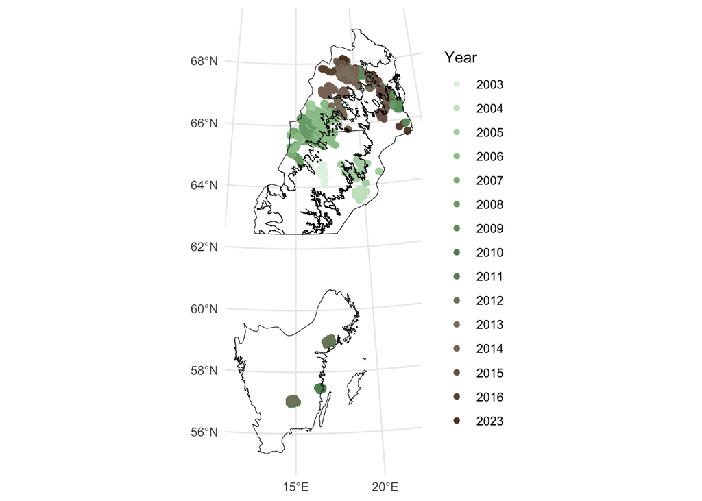

```r
moose_random_steps_sf <- st_as_sf(
  moose_random_steps,
  coords=c("x1_", "y1_"),
  crs=st_crs(3006)
)
ggplot() +
  layer_spatial(moose_random_steps_sf[moose_random_steps_sf$case_ == T,], aes(color=as.factor(year))) +
  layer_spatial(strata, fill="transparent", color="black") +
  scale_color_manual(name="Year", values = custom_green_brown) +
  theme_minimal()
```

```
In [29]:
```

```r
# adding an ID for each row (that doesn't get lost when writing to file) will be useful
# when interpolating temperatures
moose_random_steps$id <- 1:nrow(moose_random_steps)
```

# 3 Export results

```
In [30]:
```

```r
str(moose_random_steps)
```

```
rndm_stp [9,797,581 × 26] (S3: random_steps/steps_xyt/steps_xy/tbl_df/tbl/data.frame)
 $ animal_id         : chr [1:9797581] "aa_ac_04_028" "aa_ac_04_028" "aa_ac_04_028" "aa_ac_04_028" ...
 $ x1_               : num [1:9797581] 509475 509475 509475 509475 509475 ...
 $ x2_               : num [1:9797581] 509485 509459 509527 509514 509355 ...
 $ y1_               : num [1:9797581] 7280977 7280977 7280977 7280977 7280977 ...
 $ y2_               : num [1:9797581] 7280973 7280979 7281166 7280985 7280895 ...
 $ sl_               : num [1:9797581] 10.1 16.7 196.3 39.9 145.7 ...
 $ ta_               : num [1:9797581] -1.448 1.859 0.184 -0.913 2.617 ...
 $ collar_id         : chr [1:9797581] "VAS_01025" "VAS_01025" "VAS_01025" "VAS_01025" ...
 $ collar_temperature: int [1:9797581] 8 8 8 8 8 8 8 8 8 8 ...
 $ birth_year        : int [1:9797581] 2001 2001 2001 2001 2001 2001 2001 2001 2001 2001 ...
 $ long              : num [1:9797581] 15.2 15.2 15.2 15.2 15.2 ...
 $ lat               : num [1:9797581] 65.7 65.7 65.7 65.7 65.7 ...
 $ strata            : Factor w/ 4 levels "boreal alpine",..: 1 1 1 1 1 1 1 1 1 1 ...
 $ year              : num [1:9797581] 2005 2005 2005 2005 2005 ...
 $ season            : chr [1:9797581] "summer" "summer" "summer" "summer" ...
 $ season_year       : num [1:9797581] 2005 2005 2005 2005 2005 ...
 $ burst_            : num [1:9797581] 1 1 1 1 1 1 1 1 1 1 ...
 $ t1_               : POSIXct[1:9797581], format: "2005-06-01 06:00:00" "2005-06-01 06:00:00" ...
 $ t2_               : POSIXct[1:9797581], format: "2005-06-01 09:00:00" "2005-06-01 09:00:00" ...
 $ dt_               : 'difftime' num [1:9797581] 2.99472222222222 2.99472222222222 2.99472222222222 2.99472222222222 ...
  ..- attr(*, "units")= chr "hours"
 $ hour_t1           : num [1:9797581] 6 6 6 6 6 6 6 6 6 6 ...
 $ hour_t2           : num [1:9797581] 9 9 9 9 9 9 9 9 9 9 ...
 $ case_             : logi [1:9797581] TRUE FALSE FALSE FALSE FALSE FALSE ...
 $ step_id_          : num [1:9797581] 3 3 3 3 3 3 3 3 3 3 ...
 $ y                 : num [1:9797581] 1 0 0 0 0 0 0 0 0 0 ...
 $ id                : int [1:9797581] 1 2 3 4 5 6 7 8 9 10 ...
 - attr(*, ".internal.selfref")=<externalptr>
 - attr(*, "sl_")=List of 3
  ..$ name  : chr "gamma"
  ..$ params:List of 2
  .. ..$ shape: num 0.675
  .. ..$ scale: num 382
  ..$ vcov  : num [1:2, 1:2] 2.60 -2.27e-03 -2.27e-03 4.03e-06
  .. ..- attr(*, "dimnames")=List of 2
  .. .. ..$ : chr [1:2] "scale" "shape"
  .. .. ..$ : chr [1:2] "scale" "shape"
  ..- attr(*, "class")= chr [1:4] "gamma_distr" "sl_distr" "amt_distr" "list"
 - attr(*, "ta_")=List of 3
  ..$ name  : chr "vonmises"
  ..$ params:List of 2
  .. ..$ kappa: num 0.177
  .. ..$ mu   : 'circular' num 0
  .. .. ..- attr(*, "circularp")=List of 6
  .. .. .. ..$ type    : chr "angles"
  .. .. .. ..$ units   : chr "radians"
  .. .. .. ..$ template: chr "none"
  .. .. .. ..$ modulo  : chr "asis"
  .. .. .. ..$ zero    : num 0
  .. .. .. ..$ rotation: chr "counter"
  ..$ vcov  : num [1, 1] 0.00355
  ..- attr(*, "class")= chr [1:4] "vonmises_distr" "ta_distr" "amt_distr" "list"
 - attr(*, "n_control_")= num 30
```

```
In [31]:
```

```r
save(moose_random_steps, file='../data/localisations/moose_random_steps.RData')
```